# Notebook

## 결혼하기에 적절한 나이차이는 얼마일까?

- 남,녀 나이차이와 이혼률과의 관계

### 데이터 요약

- **결혼 통계 데이터**  
  1991~2018년 기간 약 900만건의 결혼 정보 데이터  
  출처 : 통계청 마이크로데이터(https://mdis.kostat.go.kr/index.do) 인구$\cdot$가구-인구동향조사-혼인 연간자료  
  **year** : 결혼 연도  
  **month** : 결혼 월  
  **male_age** : 결혼 당시 남자의 나이  
  **female_age** : 결혼 당시 여자의 나이  
  **data_year** : 데이터 수집 연도  
  **age_gap** : 부부의 나이차(=신랑의 나이 - 아내의 나이)

|  | year | month | male_age | female_age | data_year | age_gap |
| --- | --- | --- | --- | --- | --- | --- |
| 3493316 | 2000 | 2 | 25 | 25 | 2000 | 0 |
| 2358285 | 1996 | 12 | 30 | 26 | 1997 | 4 |
| 3792478 | 2000 | 12 | 36 | 33 | 2001 | 3 |
| 5830835 | 2007 | 7 | 37 | 30 | 2007 | 7 |
| 5745928 | 2007 | 3 | 55 | 47 | 2007 | 8 |

- **이혼 통계 데이터**  
  2018년 기준 약 26만건의 이혼 정보 데이터  
  출처 : 통계청 마이크로데이터(https://mdis.kostat.go.kr/index.do) 인구$\cdot$가구-인구동향조사-이혼 연간자료  
  **divorce_year** : 이혼 연도  
  **male_divorce** : 이혼 당시 남자의 나이  
  **female_age** : 이혼 당시 여자의 나이  
  **live_together** : 결혼 생활 기간  
  **age_gap** : 부부의 나이차(=신랑의 나이 - 아내의 나이)

|  | divorce_year | male_divorce | female_divorce | live_together | age_gap |
| --- | --- | --- | --- | --- | --- |
| 37649 | 2012 | 38 | 37 | 13 | 1 |
| 6642 | 2018 | 63 | 60 | 36 | 3 |
| 74023 | 2018 | 31 | 40 | 7 | -9 |
| 15942 | 2018 | 57 | 54 | 28 | 3 |
| 108105 | 2018 | 69 | 68 | 0 | 1 |

### 분석 개요

- 처음에는 **2018년** 나이차별 **결혼**비율과 **2018년** 나이차별 **이혼**비율 데이터를 이용해 분석을시도했으나, 나이차별 결혼비율은 연도별로 유의미한 차이를 보였기 때문에 과거 결혼 데이터들을 종합해 사용했다.(이혼은 결혼생활기간 지속 후 발생하는 사건이기 때문)
- 통계청에 게시된 결혼 통계자료는 1991년이 가장 오래된 것이므로 2018년 기준 결혼 생활 기간이 27년 이하인 부부들까지만 결혼 당시 나이차 분포를 알 수 있다.
- 만약 나이차이가 이혼률에 영향을 미치지 않는다고 가정하면 2018년 기준 결혼 생활기간이 n년인 부부의 나이차이별 이혼률은 n년전 결혼 한 부부들의 나이차이 분포와 동일할 것이다.
- 이를 카이제곱 적합도 검정을 이용해 가설을 검정하고, 유의미한 차이가 발생하면 시각화를 통해 **몇살의 나이차이가 결혼에 적절한지**를 살펴보고자 한다.

## 결혼시 남편과 아내의 나이 추세

### 결혼시 남성, 여성의 평균 연령

[interactive chart not shown]

- 결혼 평균 나이는 연도가 지남에 따라 증가하는 추세를 보인다.
- 결혼시 나이차의 경우 전체적으로 감소하는 추세이며 1991년에는 3.3살 정도 차이가났었고, 2018년에는 2.7살 정도의 차이가 난다.

### 과거와 현재 결혼시 부부들의 나이차

*남10+의 경우 남자가 여자보다 10살 연상을 의미

[interactive chart not shown]

### 2018년 기준 이혼 부부들의 결혼 생활 기간 분포

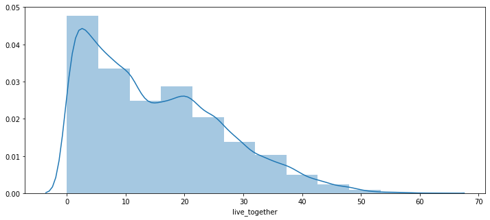

> 결혼 생활기간이 늘어날수록 이혼률은 낮아짐을 알 수 있다. 그래프를 통해 결혼 후 5년이내에 이혼한 부부들의 비율이 가장 많음을 알 수 있다.  
> 결혼 생활 기간이 25년 이내인 부부의 비율은 전체의 80% 정도이다.

## 적절한 나이차 탐색

### 결혼/이혼 부부와 나이차 분포 그래프

(나이차) = (남자나이)-(여자나이), -12~12

[interactive chart not shown]

- 결혼과 이혼 모두 **나이차가 0(동갑)~4(남자 연상) 이내에서 빈도가 많음**을 알 수 있다.(각 나이차당 10%이상의 비율 차지)
- 여자가 연상인 경우보다는 남자가 연상인 경우가 결혼, 이혼 모두 많다.
- 나이차가 0~5일때 빨간색 그래프가 파란색 그래프 위에 위치해있으며 이는 이 나이차에서 결혼한 인원은 많지만 이혼한 인원은 그에 대비해 적음을 알 수 있다.

[interactive chart not shown]

- 나이차가 0~4인 부부들중 2018년에 이혼한 부부의 비율은 1%에 미치지 못했지만, 나이차가 -12인 부부들중 이혼한 부부의 비율은 1.7%로 두 그룹의 이혼 비율은 거의 2배가까이 차이가 남을 알 수 있다.
- **나이차의 절댓값이 커질수록 2018년에 이혼한 부부의 비율이 많음**을 알 수 있다.
- 즉 나이차가 적은 부부가 그렇지 않은 부부에 비해 **원만한 부부관계를 지속**할 확률이 높다고 해석가능하다.

### 가설검정

귀무가설 $H_0$ : 모든 나이차에서 2018년에 이혼한 부부의 비율(=p)은 같다.  
이를 검정하기 위해 카이제곱 동질성 검정을 시행한다.

```
Chi square 검정통계량 값 :  2430.3089171697975
```

### 결혼 생활기간에 따른 이혼 비율

결혼 생활기간 10년을 전후로 비교

[interactive chart not shown]

- y축 범위에서 알 수 있듯이 결혼 생활 기간이 짧은 부부가 2018년에 이혼한 비율이 높았다.
- **결혼 생활기간이 짧을수록 나이차가 이혼여부에 영향을 많이 미침**을 알 수 있다.
- 결혼 생활기간이 10년 이상인 부부의 경우 여자가 8살이상 연상인 경우(나이차 : -8~-12) 이혼 비율이 오히려 다른 나이차보다 낮았다.

### 결론

- 부부의 **나이차가 많아질수록 이혼할 확률이 높아진다.**
- **여자1살 연상~ 남자 5살 연상** 부부가 이혼할 확률이 다른 연령차에 비해 다소 낮다.
- 여성의 나이가 남성에 비해 많은 부부의 경우 결혼 생활 초기에는 이혼 할 확률이 높지만 시간이 지날수록 다른 나이차에 비해 이혼할 확률이 감소한다.